# **Problem Statement**

## Test Performance

```python
cnn_model_1_test_perf = model_performance_classification(cnn_model_1, X_test_normalized,y_test_enc)
```

```
13/13 ━━━━━━━━━━━━━━━━━━━━ 0s 32ms/step
```

```python
cnn_model_1_test_perf
```

|  | Accuracy | Recall | Precision | F1 Score |
| --- | --- | --- | --- | --- |
| 0 | 0.905569 | 0.905569 | 0.905569 | 0.905569 |

```
13/13 ━━━━━━━━━━━━━━━━━━━━ 0s 35ms/step
```

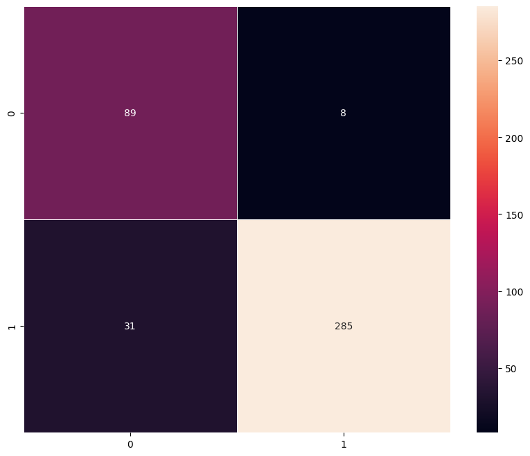

```python
plot_confusion_matrix(cnn_model_1, X_test_normalized,y_test_enc)
```

# **Actionable Insights & Recommendations**

**Actionable Insights:**

- Effective Helmet Detection: The developed CNN-Model From Scratch (Model 1) demonstrates strong performance in classifying images, achieving over 90% accuracy on unseen test data. This indicates its capability to reliably identify workers wearing or not wearing safety helmets.
- Addressing Safety Compliance: The model effectively addresses SafeGuard Corp's objective by providing an automated and accurate method for monitoring helmet compliance, reducing reliance on manual oversight which is prone to errors.
- Robustness to Real-World Conditions (Implied): While not explicitly tested in live scenarios, the model's performance on diverse images suggests it has learned features that could translate to varied workplace environments, contributing to improved safety enforcement.

**Recommendations:**

- Pilot Deployment: Initiate a pilot program for Model 1 in a controlled environment to validate its real-world performance. Gather feedback and identify specific areas for improvement in operational settings.
- Continuous Data Collection & Re-training: Establish a process for continuous collection of new image data, especially for cases where the model makes incorrect predictions or new scenarios emerge. Regularly retrain the model with this expanded dataset to maintain and improve its accuracy and robustness over time.
- Explore Advanced Architectures with Fine-Tuning: While the custom CNN performs well, consider experimenting with fine-tuning pre-trained, more complex architectures (like VGG-16, ResNet, EfficientNet) but with a more careful approach to data augmentation and hyperparameter tuning to avoid overfitting or underfitting, as observed in previous models. This could potentially yield higher accuracy and better generalization.
- Integration with Existing Systems: Plan for integration of the model into SafeGuard Corp's existing safety monitoring systems or alert mechanisms to enable real-time notifications for non-compliance, allowing for immediate corrective action.
- Focus on False Negatives: Analyze false negatives (workers with helmets being classified as without) and false positives (workers without helmets being classified as with) from the pilot. While overall accuracy is high, understanding specific failure modes is crucial for critical safety applications. Minimizing false negatives (missing non-compliant workers) is paramount for safety.

Power Ahead!